# capitulo_6

Gabriel Omar Maya Briseño

2025-04-03

```r
library(knitr)
library(tidyverse)
library(discrtr) # A companion package for the book Introduction to Discrete Choice Analysis with `R`
library(dplyr) # A Grammar of Data Manipulation
library(ggplot2) # Create Elegant Data Visualisations Using the Grammar of Graphics
library(mlogit) # Multinomial Logit Models
library(readr) # Read Rectangular Text Data
library(gplots) # Various R Programming Tools for Plotting Data
library(ggmosaic) # Mosaic Plots in the 'ggplot2' Framework
library(treemapify)
library(ggridges)
library(ggalluvial)
library(kableExtra) # Construct Complex Table with kable and Pipe Syntax
library(plotly) # Create interactive web graphics
library(tidyr) # Tidy messy data
#library(webshot2) # Take screenshots of web pages

library(evd)
```

# Cargar el conjunto de datos `Heating`

```r
data("Heating")
glimpse(Heating)
```

```
## Rows: 900
## Columns: 16
## $ idcase <dbl> 1, 2, 3, 4, 5, 6, 7, 8, 9, 10, 11, 12, 13, 14, 15, 16, 17, 18, …
## $ depvar <fct> gc, gc, gc, er, er, gc, gc, gc, gc, gc, gc, gc, gc, gr, gc, gr,…
## $ ic.gc  <dbl> 866.00, 727.93, 599.48, 835.17, 755.59, 666.11, 670.10, 778.03,…
## $ ic.gr  <dbl> 962.64, 758.89, 783.05, 793.06, 846.29, 841.71, 941.25, 1022.10…
## $ ic.ec  <dbl> 859.90, 796.82, 719.86, 761.25, 858.86, 693.74, 633.63, 813.33,…
## $ ic.er  <dbl> 995.76, 894.69, 900.11, 831.04, 985.64, 862.56, 952.30, 1012.30…
## $ ic.hp  <dbl> 1135.50, 968.90, 1048.30, 1048.70, 883.05, 859.18, 1086.80, 990…
## $ oc.gc  <dbl> 199.69, 168.66, 165.58, 180.88, 174.91, 135.67, 191.84, 187.61,…
## $ oc.gr  <dbl> 151.72, 168.66, 137.80, 147.14, 138.90, 140.97, 147.57, 158.66,…
## $ oc.ec  <dbl> 553.34, 520.24, 439.06, 483.00, 404.41, 398.22, 478.36, 502.40,…
## $ oc.er  <dbl> 505.60, 486.49, 404.74, 425.22, 389.52, 371.04, 445.97, 464.77,…
## $ oc.hp  <dbl> 237.88, 199.19, 171.47, 222.95, 178.49, 209.27, 236.99, 203.78,…
## $ income <dbl> 7, 5, 4, 2, 2, 6, 4, 6, 5, 7, 5, 7, 5, 2, 3, 4, 6, 7, 6, 7, 5, …
## $ agehed <dbl> 25, 60, 65, 50, 25, 65, 35, 20, 60, 20, 60, 25, 35, 30, 35, 35,…
## $ rooms  <dbl> 6, 5, 2, 4, 6, 7, 2, 7, 6, 2, 6, 4, 3, 6, 2, 4, 2, 4, 2, 4, 5, …
## $ region <fct> ncostl, scostl, ncostl, scostl, valley, scostl, scostl, valley,…
```

# EDA

## Resúmenes estadísticos

```r
Proportion <- Heating %>% group_by(depvar) %>% summarise(no_rows = n())

df <- data.frame(System = c("Gas Central", "Gas Room", "Electric Central", "Electric Room", "Heat Pump"),
                 Installation = c(mean(Heating$ic.gc), mean(Heating$ic.gr),
                                  mean(Heating$ic.ec), mean(Heating$ic.er),
                                  mean(Heating$ic.hp)),
                 Operation = c(mean(Heating$oc.gc), mean(Heating$oc.gr),
                               mean(Heating$oc.ec), mean(Heating$oc.er),
                               mean(Heating$oc.hp)),
                 Proportion = Proportion$no_rows/900)

df %>% kable() %>% kable_styling()
```

| System | Installation | Operation | Proportion |
| --- | --- | --- | --- |
| Gas Central | 776.8266 | 172.1158 | 0.6366667 |
| Gas Room | 921.7702 | 154.4714 | 0.1433333 |
| Electric Central | 824.5435 | 476.8030 | 0.0711111 |
| Electric Room | 983.9280 | 429.7299 | 0.0933333 |
| Heat Pump | 1046.4813 | 219.2993 | 0.0555556 |

```r
Heating %>% select(13:16) %>% summary()
```

```
##      income          agehed          rooms          region
##  Min.   :2.000   Min.   :20.00   Min.   :2.000   valley:177
##  1st Qu.:3.000   1st Qu.:30.00   1st Qu.:3.000   scostl:361
##  Median :5.000   Median :45.00   Median :4.000   mountn:102
##  Mean   :4.641   Mean   :42.94   Mean   :4.424   ncostl:260
##  3rd Qu.:6.000   3rd Qu.:55.00   3rd Qu.:6.000
##  Max.   :7.000   Max.   :65.00   Max.   :7.000
```

```r
H <- Heating %>% mlogit.data(shape = "wide", choice="depvar", varying=c(3:12))
```

Estas funciones sólo incluyen el costo de instalación de cada sistema (ic). La función mlogit puede ser utilizada para estimar el modelo, utilizando electric central system (ec) como nivel de referencia:

```r
model1 <- mlogit(depvar~ ic, Heating, shape="wide", choice="depvar", reflevel = "ec", varying=c(3:7))
summary(model1)
```

```
##
## Call:
## mlogit(formula = depvar ~ ic, data = Heating, reflevel = "ec",
##     shape = "wide", choice = "depvar", varying = c(3:7), method = "nr")
##
## Frequencies of alternatives:choice
##       ec       er       gc       gr       hp
## 0.071111 0.093333 0.636667 0.143333 0.055556
##
## nr method
## 6 iterations, 0h:0m:0s
## g'(-H)^-1g = 1.02E-05
## successive function values within tolerance limits
##
## Coefficients :
##                   Estimate  Std. Error z-value  Pr(>|z|)
## (Intercept):er  0.53681271  0.19194838  2.7967  0.005164 **
## (Intercept):gc  2.11877361  0.13413083 15.7963 < 2.2e-16 ***
## (Intercept):gr  0.86420949  0.16435236  5.2583 1.454e-07 ***
## (Intercept):hp  0.12259544  0.23188795  0.5287  0.597025
## ic             -0.00168108  0.00061843 -2.7183  0.006561 **
## ---
## Signif. codes:  0 '***' 0.001 '**' 0.01 '*' 0.05 '.' 0.1 ' ' 1
##
## Log-Likelihood: -1018.5
## McFadden R^2:  0.0036292
## Likelihood ratio test : chisq = 7.4197 (p.value = 0.0064514)
```

## Interpretacion de los coeficientes

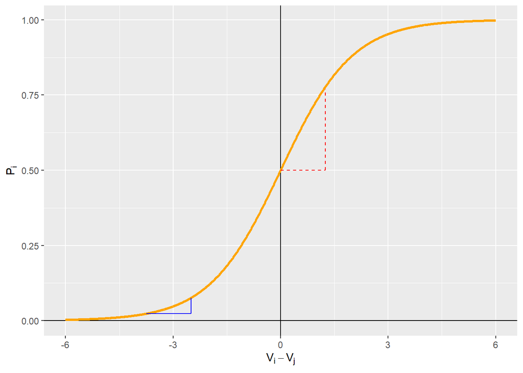

```r
mu <- 0
sigma <- 1

df <- tibble(x=seq(from=-6+mu, to=6+mu, by=0.01 ),
             f=plogis(x, location=mu, scale=sigma))



logit_plot <- ggplot(df)+
  geom_hline(yintercept = 0)+
  geom_vline(xintercept = 0)+
  geom_line(aes(x,f), color="orange", linewidth=1.2)+
  xlab(expression(paste(V[i]-V[j])))+
  ylab(expression(paste(P[i])))+
   annotate("segment", x = -3.75, xend = -2.5, y = 0.024, yend = 0.024, colour = "blue", linetype = "solid")+
   annotate("segment", x = -2.5, xend = -2.5, y = 0.024, yend = 0.075, colour = "blue", linetype = "solid")+
   annotate("segment", x = 0, xend = 1.25, y = 0.5, yend = 0.5, colour = "red", linetype = "dashed")+
   annotate("segment", x = 1.25, xend = 1.25, y = 0.5, yend = 0.77, colour = "red", linetype = "dashed")

logit_plot
```

## Efectos marginales

Simulamos tres situaciones: cuando los costos tienen el valor mínimo, promedio y máximo. Para esto, se copia la primera fila de los datos para cada uno de los niveles que se simularán:

```r
ic_min <- Heating[1, ]
ic_mean <- Heating[1, ]
ic_max <- Heating[1, ]
```

A continuación se definen los siguientes vectores para calcular el valor mínimo, la media y el máximo de los costos de instalación para cada sistema de calefacción:

```r
min_cost <- Heating %>% select(starts_with("ic")) %>%
                        summarise(across(.cols = everything(), min))

mean_cost <- Heating %>% select(starts_with("ic")) %>%
             summarise(across(.cols = everything(), mean))

max_cost <- Heating %>% select(starts_with("ic")) %>%
                        summarise(across(.cols = everything(), max))
```

Ahora se reemplaza el costo de instalación con estos vectores:

```r
ic_min[3:7] <- min_cost
ic_mean[3:7] <- mean_cost
ic_max[3:7] <- max_cost
```

Por ejemplo, en el caso de costos máximos tenemos:

```r
head(ic_max)
```

```
##   idcase depvar  ic.gc ic.gr  ic.ec  ic.er  ic.hp  oc.gc  oc.gr  oc.ec oc.er
## 1      1     gc 1158.9  1344 1230.5 1496.3 1679.8 199.69 151.72 553.34 505.6
##    oc.hp income agehed rooms region
## 1 237.88      7     25     6 ncostl
```

Dados los diferentes valores de instalación (mínimo, medio y máximo), podemos predecir las probabilidades como sigue (nótese que al predecir con un modelo mlogit requiere que los datos nuevos estén en formato por longitud, por lo que se cambia usando la función mlogit.data):

```r
p_model1_ic_min <- predict(model1, newdata = mlogit.data(ic_min, shape = "wide", choice = "depvar", varying = 3:7))

p_model1_ic_mean <- predict(model1, newdata = mlogit.data(ic_mean, shape = "wide", choice = "depvar", varying = 3:7))

p_model1_ic_max <- predict(model1, newdata = mlogit.data(ic_max, shape = "wide", choice = "depvar", varying = 3:7))
```

Notemos que las probabilidades y los costos no están en el mismo orden, por lo que es necesario reordenarlos:

```r
min_cost
```

```
##    ic.gc  ic.gr  ic.ec  ic.er  ic.hp
## 1 431.83 574.94 469.61 546.82 532.32
```

```r
p_model1_ic_min
```

```
##         ec         er         gc         gr         hp
## 0.06956900 0.10451552 0.61683645 0.13830486 0.07077416
```

Las probabilidades y sus respectivos costos se resumen a continuación:

```r
data.frame(System = c("Electric Central", "Electric Room", "Gas Central", "Gas Room", "Heat Pump"),
           ic_min = ic_min %>% select(ic.ec, ic.er, ic.gc, ic.gr, ic.hp) %>% t() %>% as.numeric() %>%
                    round(1),
           p_min = p_model1_ic_min %>% as.numeric() %>% round(3),
           ic_mean = ic_mean %>% select(ic.ec, ic.er, ic.gc, ic.gr, ic.hp) %>% t() %>% as.numeric() %>%
                     round(1),
          p_mean = p_model1_ic_mean %>% as.numeric() %>% round(3),
          ic_max = ic_max %>% select(ic.ec, ic.er, ic.gc, ic.gr, ic.hp) %>% t() %>% as.numeric() %>%
                   round(1),
          p_max = p_model1_ic_max %>% as.numeric() %>% round(3)) %>%
          kable(col.names = c("System", "Cost", "Probability", "Cost", "Probability", "Cost", "Probability"),
          digits = 3) %>% kable_styling() %>%
          add_header_above(c(" " = 1, "Minimum Cost" = 2, "Mean Cost" = 2, "Maximum Cost" = 2))
```

| System | Minimum Cost Cost | Minimum Cost Probability | Mean Cost Cost | Mean Cost Probability | Maximum Cost Cost | Maximum Cost Probability |
| --- | --- | --- | --- | --- | --- | --- |
| Electric Central | 469.6 | 0.070 | 824.5 | 0.071 | 1230.5 | 0.072 |
| Electric Room | 546.8 | 0.105 | 983.9 | 0.093 | 1496.3 | 0.078 |
| Gas Central | 431.8 | 0.617 | 776.8 | 0.639 | 1158.9 | 0.672 |
| Gas Room | 574.9 | 0.138 | 921.8 | 0.143 | 1344.0 | 0.140 |
| Heat Pump | 532.3 | 0.071 | 1046.5 | 0.055 | 1679.8 | 0.038 |

De acuerdo a los valores resumidos previamente, podemos calcular el efecto marginal directo del sistema gas central a los tres niveles de costo de instalación de interés como:

Costo mínimo:

```r
-0.00168108 * (1 - 0.617)
```

```
## [1] -0.0006438536
```

Costo promedio:

```r
-0.00168108 * (1 - 0.639)
```

```
## [1] -0.0006068699
```

Costo máximo

```r
-0.00168108 * (1 - 0.672)
```

```
## [1] -0.0005513942
```

Costo mínimo:

```r
-(-0.00168108 * 0.617)
```

```
## [1] 0.001037226
```

Costo promedio:

```r
-(-0.00168108 * 0.639)
```

```
## [1] 0.00107421
```

Costo máximo:

```r
-(-0.00168108 * 0.672)
```

```
## [1] 0.001129686
```

## Elasticidad

De acuerdo a los valores anteriores, podemos calcular la elasticidad de punto-directo del sistema gas central a cada nivel de costo de instalación de la siguiente manera:

Costo mínimo:

```r
-0.00168108 * 431.8 * (1 - 0.617)
```

```
## [1] -0.278016
```

Costo promedio:

```r
-0.00168108 * 776.8 * (1 - 0.639)
```

```
## [1] -0.4714165
```

Costo máximo

```r
-0.00168108 * 1158.9 * (1 - 0.672)
```

```
## [1] -0.6390108
```

Las elasticidades punto-transversal del sistema gas central a los tres niveles de interés de costo de instalación son:

Costo mínimo

```r
-(-0.00168108 * 431.8 * 0.617)
```

```
## [1] 0.4478743
```

Costo promedio

```r
-(-0.00168108 * 776.8 * 0.639)
```

```
## [1] 0.8344464
```

Costo máximo

```r
-(-0.00168108 * 1158.9 * 0.672)
```

```
## [1] 1.309193
```

## Efectos marginales

```r
# Calculate the marginal effects with respect to attribute "ic"
# Type of effects to compute: relative for probability, absolute for attribute
effects(model1, covariate = "ic", type = "ra",
        data = mlogit.data(ic_min, shape = "wide", choice = "depvar", varying = 3:7))
```

```
##               ec            er            gc            gr            hp
## ec -0.0015641293  0.0001169511  0.0001169511  0.0001169511  0.0001169511
## er  0.0001756990 -0.0015053814  0.0001756990  0.0001756990  0.0001756990
## gc  0.0010369517  0.0010369517 -0.0006441287  0.0010369517  0.0010369517
## gr  0.0002325016  0.0002325016  0.0002325016 -0.0014485788  0.0002325016
## hp  0.0001189771  0.0001189771  0.0001189771  0.0001189770 -0.0015621033
```

```r
effects(model1, covariate = "ic", type = "ra", data = mlogit.data(ic_mean, shape = "wide",
        choice = "depvar", varying = 3:7))
```

```
##               ec            er            gc            gr            hp
## ec -1.562008e-03  1.190728e-04  1.190728e-04  1.190728e-04  0.0001190728
## er  1.558057e-04 -1.525275e-03  1.558056e-04  1.558056e-04  0.0001558056
## gc  1.073548e-03  1.073548e-03 -6.075323e-04  1.073548e-03  0.0010735481
## gr  2.399663e-04  2.399663e-04  2.399663e-04 -1.441114e-03  0.0002399663
## hp  9.268762e-05  9.268762e-05  9.268762e-05  9.268762e-05 -0.0015883927
```

Y los efectos marginales para los valores máximos de costo de instalación son:

```r
effects(model1, covariate = "ic", type = "ra", data = mlogit.data(ic_max, shape = "wide",
        choice = "depvar", varying = 3:7))
```

```
##               ec            er            gc            gr            hp
## ec -1.560758e-03  1.203225e-04  1.203225e-04  0.0001203225  0.0001203225
## er  1.316513e-04 -1.549429e-03  1.316514e-04  0.0001316513  0.0001316514
## gc  1.129256e-03  1.129256e-03 -5.518241e-04  0.0011292563  0.0011292563
## gr  2.359411e-04  2.359411e-04  2.359412e-04 -0.0014451392  0.0002359412
## hp  6.390908e-05  6.390909e-05  6.390909e-05  0.0000639091 -0.0016171713
```

## Calculo de elasticidad

```r
effects(model1, covariate = "ic", type = "rr", data = mlogit.data(ic_min, shape = "wide", choice = "depvar",
        varying = 3:7))
```

```
##             ec          er          gc          gr          hp
## ec -0.73453075  0.05492140  0.05492140  0.05492140  0.05492140
## er  0.09607572 -0.82317265  0.09607573  0.09607572  0.09607572
## gc  0.44778685  0.44778685 -0.27815410  0.44778684  0.44778685
## gr  0.13367447  0.13367447  0.13367448 -0.83284588  0.13367448
## hp  0.06333387  0.06333387  0.06333387  0.06333386 -0.83153884
```

Los valores en la diagonal principal de la tabla son las elasticidades punto-directo, mientras las demás son las punto-transversal. Los efectos pueden ser calculados para varios niveles de la covariable de interés, por ejemplo, para los valores promedio y máximo de los costos de instalación:

```r
effects(model1, covariate = "ic", type = "rr", data = mlogit.data(ic_mean, shape = "wide", choice = "depvar",
        varying = 3:7))
```

```
##             ec          er          gc          gr          hp
## ec -1.28794317  0.09818068  0.09818067  0.09818069  0.09818068
## er  0.15330155 -1.50076056  0.15330153  0.15330154  0.15330154
## gc  0.83396070  0.83396069 -0.47194728  0.83396070  0.83396070
## gr  0.22119376  0.22119375  0.22119375 -1.32837610  0.22119376
## hp  0.09699586  0.09699586  0.09699586  0.09699586 -1.66222324
```

```r
effects(model1, covariate = "ic", type = "rr", data = mlogit.data(ic_max, shape = "wide", choice = "depvar",
        varying = 3:7))
```

```
##            ec         er         gc         gr         hp
## ec -1.9205126  0.1480568  0.1480568  0.1480568  0.1480568
## er  0.1969899 -2.3184107  0.1969899  0.1969899  0.1969899
## gc  1.3086951  1.3086951 -0.6395089  1.3086951  1.3086951
## gr  0.3171049  0.3171049  0.3171049 -1.9422671  0.3171049
## hp  0.1073545  0.1073545  0.1073545  0.1073545 -2.7165243
```

## Una observacion acerca de los atributos cualitativos

En el conjunto de datos de sistemas de calefacción, por ejemplo, existe una variable cualitativa (dummy) que indica la región de residencia de la decisora:

```r
summary(Heating$region)
```

```
## valley scostl mountn ncostl
##    177    361    102    260
```

Para ilustrar esto, estimaremos un segundo modelo que considera la variable con las regiones:

```r
model2 <- mlogit(depvar ~ ic | region, Heating, shape = "wide", choice = "depvar", reflevel = "ec",
                 varying = c(3:7))

summary(model2)
```

```
##
## Call:
## mlogit(formula = depvar ~ ic | region, data = Heating, reflevel = "ec",
##     shape = "wide", choice = "depvar", varying = c(3:7), method = "nr")
##
## Frequencies of alternatives:choice
##       ec       er       gc       gr       hp
## 0.071111 0.093333 0.636667 0.143333 0.055556
##
## nr method
## 6 iterations, 0h:0m:0s
## g'(-H)^-1g = 0.000192
## successive function values within tolerance limits
##
## Coefficients :
##                    Estimate  Std. Error z-value  Pr(>|z|)
## (Intercept):er   0.60026296  0.37803680  1.5878  0.112322
## (Intercept):gc   2.03028891  0.29516076  6.8786 6.045e-12 ***
## (Intercept):gr   0.89557390  0.34321429  2.6094  0.009071 **
## (Intercept):hp   0.28142118  0.42207287  0.6668  0.504926
## ic              -0.00166573  0.00062007 -2.6864  0.007223 **
## regionscostl:er  0.04953858  0.44699277  0.1108  0.911754
## regionscostl:gc  0.07371855  0.36192685  0.2037  0.838601
## regionscostl:gr  0.10263835  0.41405948  0.2479  0.804225
## regionscostl:hp -0.14496763  0.50052467 -0.2896  0.772098
## regionmountn:er -0.02228435  0.59062797 -0.0377  0.969903
## regionmountn:gc -0.08617193  0.47825549 -0.1802  0.857012
## regionmountn:gr  0.03599409  0.54612045  0.0659  0.947451
## regionmountn:hp -0.03937414  0.65470562 -0.0601  0.952044
## regionncostl:er -0.33843774  0.49386054 -0.6853  0.493161
## regionncostl:gc  0.23183246  0.38396435  0.6038  0.545986
## regionncostl:gr -0.32954624  0.45479104 -0.7246  0.468691
## regionncostl:hp -0.39942540  0.55412324 -0.7208  0.471018
## ---
## Signif. codes:  0 '***' 0.001 '**' 0.01 '*' 0.05 '.' 0.1 ' ' 1
##
## Log-Likelihood: -1012.5
## McFadden R^2:  0.0094891
## Likelihood ratio test : chisq = 19.4 (p.value = 0.11122)
```

```r
ic_mean_region <- ic_mean %>% mutate(count=4) %>% uncount(count)

ic_mean_region$region <- c("valley", "scostl", "mountn", "ncostl")

head(ic_mean_region)
```

```
##       idcase depvar    ic.gc    ic.gr    ic.ec   ic.er    ic.hp  oc.gc  oc.gr
## 1...1      1     gc 776.8266 921.7702 824.5435 983.928 1046.481 199.69 151.72
## 1...2      1     gc 776.8266 921.7702 824.5435 983.928 1046.481 199.69 151.72
## 1...3      1     gc 776.8266 921.7702 824.5435 983.928 1046.481 199.69 151.72
## 1...4      1     gc 776.8266 921.7702 824.5435 983.928 1046.481 199.69 151.72
##        oc.ec oc.er  oc.hp income agehed rooms region
## 1...1 553.34 505.6 237.88      7     25     6 valley
## 1...2 553.34 505.6 237.88      7     25     6 scostl
## 1...3 553.34 505.6 237.88      7     25     6 mountn
## 1...4 553.34 505.6 237.88      7     25     6 ncostl
```

Luego se calculan las probabilidades asociadas a cada región y sistema de calefacción. Nótese que para cada región, la suma de las probabilidades es igual a 1.

```r
p_region_ic_mean <- data.frame(Region = c("valley", "scostl", "mountn", "ncostl"),
                               predict(model2, newdata = mlogit.data(ic_mean_region, shape = "wide",
                               choice = "depvar", varying = 3:7),
                               outcome = FALSE))

p_region_ic_mean
```

```
##   Region         ec         er        gc        gr         hp
## 1 valley 0.06893601 0.06868371 0.7167905 0.1032603 0.04232956
## 2 scostl 0.07709246 0.10537150 0.5832442 0.1664375 0.06785436
## 3 mountn 0.07330246 0.10244901 0.6044788 0.1526602 0.06710956
## 4 ncostl 0.06922558 0.10166470 0.6145323 0.1597530 0.05482440
```

Los efectos marginales de cambiar valley por cualquiera de las otras regiones son:

```r
data.frame (Effect = c("valley to scostl", "valley to mountn", "valley to ncostl"),
            rbind (p_region_ic_mean[2, 2:6] - p_region_ic_mean[1, 2:6],
                   p_region_ic_mean[3, 2:6] - p_region_ic_mean[1, 2:6],
                   p_region_ic_mean[4, 2:6] - p_region_ic_mean[1, 2:6]))
```

```
##             Effect           ec         er         gc         gr         hp
## 2 valley to scostl 0.0081564496 0.03668779 -0.1335463 0.06317722 0.02552480
## 3 valley to mountn 0.0043664503 0.03376531 -0.1123117 0.04939991 0.02478000
## 4 valley to ncostl 0.0002895745 0.03298099 -0.1022582 0.05649277 0.01249484
```

## Disposicion a pagar y tasa de descuento

El modelo es estimado de la siguiente manera:

```r
model3 <- mlogit(depvar ~ ic + oc, Heating, shape = "wide", choice = "depvar", reflevel = "ec", varying = c(3:12))

summary(model3)
```

```
##
## Call:
## mlogit(formula = depvar ~ ic + oc, data = Heating, reflevel = "ec",
##     shape = "wide", choice = "depvar", varying = c(3:12), method = "nr")
##
## Frequencies of alternatives:choice
##       ec       er       gc       gr       hp
## 0.071111 0.093333 0.636667 0.143333 0.055556
##
## nr method
## 6 iterations, 0h:0m:0s
## g'(-H)^-1g = 9.58E-06
## successive function values within tolerance limits
##
## Coefficients :
##                   Estimate  Std. Error z-value  Pr(>|z|)
## (Intercept):er  0.19459102  0.20424212  0.9527 0.3407184
## (Intercept):gc  0.05213336  0.46598878  0.1119 0.9109210
## (Intercept):gr -1.35058266  0.50715442 -2.6631 0.0077434 **
## (Intercept):hp -1.65884594  0.44841936 -3.6993 0.0002162 ***
## ic             -0.00153315  0.00062086 -2.4694 0.0135333 *
## oc             -0.00699637  0.00155408 -4.5019 6.734e-06 ***
## ---
## Signif. codes:  0 '***' 0.001 '**' 0.01 '*' 0.05 '.' 0.1 ' ' 1
##
## Log-Likelihood: -1008.2
## McFadden R^2:  0.013691
## Likelihood ratio test : chisq = 27.99 (p.value = 8.3572e-07)
```

## Simulacion de cambios en los mercados

```r
H_rebate <- Heating %>% mutate(ic.hp=0.85*ic.hp)
```

Podemos calcular las cuotas de mercado de las políticas “hacer nada” (con el conjunto de datos Heating) y “reembolso” (con el conjunto de datos H_rebate); y comparar sus cuotas (que son los valores medios de las predicciones):

```r
data.frame(Policy = c("Do nothing", "15% rebate"),
           rbind(apply(predict(model3, newdata = mlogit.data(Heating, shape = "wide", choice = "depvar",
                       varying = c(3:12))), 2, mean),
                 apply(predict(model3, newdata = mlogit.data(H_rebate, shape = "wide", choice = "depvar",
                       varying = c(3:12))), 2, mean)))
```

```
##       Policy         ec         er        gc        gr         hp
## 1 Do nothing 0.07111111 0.09333333 0.6366667 0.1433333 0.05555556
## 2 15% rebate 0.07009125 0.09199196 0.6272957 0.1412092 0.06941196
```

## Introduccion de un sistema nuevo

Para simular esta situación, comenzamos creando una matriz modelo basada en la salida del Modelo 3:

```r
X <- model.matrix(model3)
head(X)
```

```
##   (Intercept):er (Intercept):gc (Intercept):gr (Intercept):hp      ic     oc
## 1              0              0              0              0  859.90 553.34
## 2              1              0              0              0  995.76 505.60
## 3              0              1              0              0  866.00 199.69
## 4              0              0              1              0  962.64 151.72
## 5              0              0              0              1 1135.50 237.88
## 6              0              0              0              0  796.82 520.24
```

Después, creamos una nueva alternativa copiando los atributos de electric central. En otras palabras, creamos una nueva matriz en la cual sólo se conservan las filas asociadas a electric central:

```r
alt <- index(H)$alt
Xn <- X[alt=="ec", ]
head(Xn)
```

```
##    (Intercept):er (Intercept):gc (Intercept):gr (Intercept):hp     ic     oc
## 1               0              0              0              0 859.90 553.34
## 6               0              0              0              0 796.82 520.24
## 11              0              0              0              0 719.86 439.06
## 16              0              0              0              0 761.25 483.00
## 21              0              0              0              0 858.86 404.41
## 26              0              0              0              0 693.74 398.22
```

A continuación se modifican los atributos para el nuevo sistema (+200 en ic y 0.75 de oc):

```r
Xn[, "ic"] <-  Xn[, "ic"] + 200
Xn[, "oc"] <-  Xn[, "oc"] * 0.75
head(Xn)
```

```
##    (Intercept):er (Intercept):gc (Intercept):gr (Intercept):hp      ic       oc
## 1               0              0              0              0 1059.90 415.0050
## 6               0              0              0              0  996.82 390.1800
## 11              0              0              0              0  919.86 329.2950
## 16              0              0              0              0  961.25 362.2500
## 21              0              0              0              0 1058.86 303.3075
## 26              0              0              0              0  893.74 298.6650
```

También queremos identificar los id’s de elección únicos (en otras palabras, los identificadores únicos que combinan el número de hogar y el tipo de sistema de calefacción), que agregaremos como nombres de fila al nuevo sistema.

```r
chid <- index(H)$chid
head(chid, 12)
```

```
##  [1] 1 1 1 1 1 2 2 2 2 2 3 3
```

```r
unchid <- unique(index(H)$chid)
head(unchid, 12)
```

```
##  [1]  1  2  3  4  5  6  7  8  9 10 11 12
```

```r
rownames(Xn) <- paste(unchid, 'new', sep = ".")
chidb <- c(chid, unchid)
head(Xn)
```

```
##       (Intercept):er (Intercept):gc (Intercept):gr (Intercept):hp      ic
## 1.new              0              0              0              0 1059.90
## 2.new              0              0              0              0  996.82
## 3.new              0              0              0              0  919.86
## 4.new              0              0              0              0  961.25
## 5.new              0              0              0              0 1058.86
## 6.new              0              0              0              0  893.74
##             oc
## 1.new 415.0050
## 2.new 390.1800
## 3.new 329.2950
## 4.new 362.2500
## 5.new 303.3075
## 6.new 298.6650
```

Después, podemos unir el nuevo sistema a la matriz del modelo y ordernar por id de elección:

```r
X <- rbind(X, Xn)
X <- X[order(chidb), ]
head(X,15)
```

```
##       (Intercept):er (Intercept):gc (Intercept):gr (Intercept):hp      ic
## 1                  0              0              0              0  859.90
## 2                  1              0              0              0  995.76
## 3                  0              1              0              0  866.00
## 4                  0              0              1              0  962.64
## 5                  0              0              0              1 1135.50
## 1.new              0              0              0              0 1059.90
## 6                  0              0              0              0  796.82
## 7                  1              0              0              0  894.69
## 8                  0              1              0              0  727.93
## 9                  0              0              1              0  758.89
## 10                 0              0              0              1  968.90
## 2.new              0              0              0              0  996.82
## 11                 0              0              0              0  719.86
## 12                 1              0              0              0  900.11
```

[output cut: 17 more lines]

La función predict sólo acepta en el conjunto de datos las alternativas originales y no contempla una nueva alternativa. Por esta razón es necesario calcular las probabilidades paso a paso. El siguiente chunk calcula la expresión y la suma, las cuales son necesarias para calcular las probabilidades logit:

```r
exp_Xb <- as.numeric(exp(X %*% coef(model3))) # vectors
head(exp_Xb)
```

```
## [1] 0.005573519 0.007677778 0.069066744 0.020487382 0.006319992 0.010796680
```

```r
# tapply does the sum of th exp_Xb for each chidb
sum_exp_Xb <- as.numeric(tapply(exp_Xb, sort(chidb), sum))
```

Este es el vector de probabilidades logit:

```r
P <- exp_Xb / sum_exp_Xb[sort(chidb)]
```

Ahora lo convertimos a una matriz de probabilidades logit, tal que cada fila sea la probabilidad de elección de un hogar:

```r
P <- data.frame(matrix(P, ncol = 6, byrow = TRUE))
P <- transmute(P, ec = P[, 1], er = P[, 2], gc = P[, 3], gr = P[, 4], hp = P[, 5], new = P[, 6])
```

Podemos verificar que la suma de las probabilidades para cada fila es 1:

```r
summary(rowSums(P))
```

```
##    Min. 1st Qu.  Median    Mean 3rd Qu.    Max.
##       1       1       1       1       1       1
```

La aceptación estimada del nuevo sistema es el promedio de las probabilidades obtenidas

```r
apply(P, 2, mean)
```

```
##         ec         er         gc         gr         hp        new
## 0.06311578 0.08347713 0.57145108 0.12855080 0.04977350 0.10363170
```

```r
apply(fitted(model3, outcome = FALSE), 2, mean)
```

```
##         ec         er         gc         gr         hp
## 0.07111111 0.09333333 0.63666667 0.14333333 0.05555556
```

## Simulación de resultados a nivel individual

Las probabilidades se pueden convertir para predecir alternativas usando heurística. Estas son las probabilidades predichas según el Modelo 3:

```r
p_model3 <- fitted(model3, outcome=FALSE) %>% data.frame()
```

Como acabamos de ver, estas pueden usarse para obtener las cuotas de mercado pronosticadas mediante el cálculo del promedio de las probabilidades:

```r
apply(p_model3, 2, mean)
```

```
##         ec         er         gc         gr         hp
## 0.07111111 0.09333333 0.63666667 0.14333333 0.05555556
```

Podríamos usar una regla heurística para predecir la alternativa elegida, por ejemplo, asignando el resultado a la alternativa con la probabilidad más alta. Esta heurística se implementa en el siguiente chunk:

```r
o_model3 <- p_model3 %>%
            # Group by row
            rowwise() %>%
            # Find the maximum value by row
            mutate(max_p = max(c(ec, er, gc, gr, hp))) %>% ungroup() %>%
            # Find the column that matches the highest probability
            transmute(outcome = case_when(max_p == ec ~ "ec",
                                          max_p == er ~ "er",
                                          max_p == gc ~ "gc",
                                          max_p == gr ~ "gr",
                                          max_p == hp ~ "hp"))
```

¿Qué tan frecuentes son las alternativas escogidas de acuerdo a esta heurística?

```r
table(o_model3)
```

```
## outcome
##  gc
## 900
```

## Proporción de preferencias

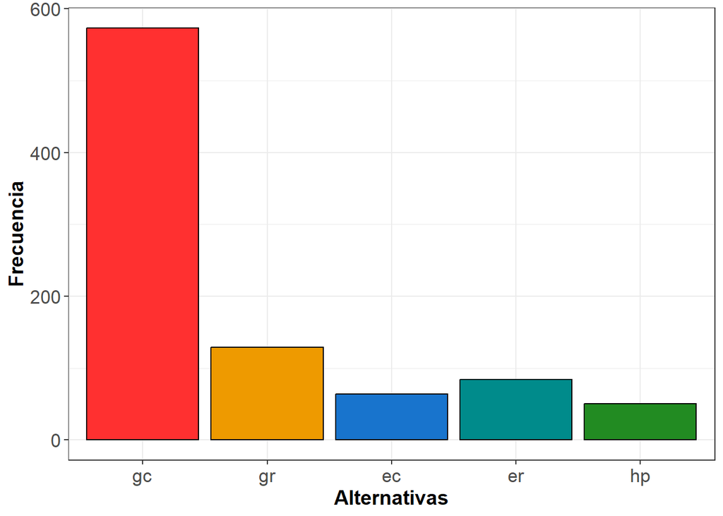

```r
my_colors <- c("gc"= "firebrick1", "gr" = "orange2" , "ec"= "dodgerblue3" , "er"= "darkcyan" , "hp"= "forestgreen")


ggplot(Heating)+
  geom_bar(aes(depvar, fill=depvar), show.legend=FALSE, color="black")+
  scale_fill_manual(values= my_colors)+
  labs(x="Alternativas", y="Frecuencia")+
  theme_bw()+
  theme(
        axis.text.x=element_text(size=13),
        axis.text.y=element_text(size=13),
        axis.title.x = element_text(face="bold", size=14),
        axis.title.y = element_text(face="bold", size=14)
        )
```

## Costos por alternativa

Antes cambiamos el conjunto de datos por longitud usando la función del package mlogit.

[figure not shown]

```r
H <- Heating %>% mlogit.data(shape = "wide", choice="depvar", varying=c(3:12))
H_long <-  as_tibble(H)
#glimpse(H_long)
levels(H$alt) <- levels(Heating$depvar)
levels(H_long$alt) <- levels(Heating$depvar)

ggplot(H_long)+
  geom_boxplot(aes(alt, ic, color=alt), show.legend = FALSE)+
  scale_color_manual(values= my_colors)+
  labs(x="Alternativas", y="Installation Cost")+
  theme_bw()+
  theme(
        axis.text.x=element_text(size=13),
        axis.text.y=element_text(size=13),
        axis.title.x = element_text(face="bold", size=14),
        axis.title.y = element_text(face="bold", size=14)
        )
```

[figure not shown]

```r
ggplot(H_long)+
  geom_boxplot(aes(alt, oc, color=alt), show.legend = FALSE)+
  scale_color_manual(values= my_colors)+
  labs(x="Alternativas", y="Operation Cost")+
  theme_bw()+
  theme(
        axis.text.x=element_text(size=13),
        axis.text.y=element_text(size=13),
        axis.title.x = element_text(face="bold", size=14),
        axis.title.y = element_text(face="bold", size=14)
        )
```

# Modelo Logit Multinomial 1

$$\begin{eqnarray}
V_{ec} &=& 0 &+& \beta_1\,ic.ec\\
V_{er} &=& \mu_{er} &+& \beta_1\,ic.er\\
V_{gc} &=& \mu_{gc} &+& \beta_1\,ic.gc\\
V_{gr} &=& \mu_{gr} &+& \beta_1\,ic.gr\\
V_{hp} &=& \mu_{hp} &+& \beta_1\,ic.hp
\end{eqnarray}$$

```r
model1 <- mlogit(depvar~ ic, Heating, shape="wide", choice="depvar", reflevel = "ec", varying=c(3:7))
summary(model1)
```

```
##
## Call:
## mlogit(formula = depvar ~ ic, data = Heating, reflevel = "ec",
##     shape = "wide", choice = "depvar", varying = c(3:7), method = "nr")
##
## Frequencies of alternatives:choice
##       ec       er       gc       gr       hp
## 0.071111 0.093333 0.636667 0.143333 0.055556
##
## nr method
## 6 iterations, 0h:0m:0s
## g'(-H)^-1g = 1.02E-05
## successive function values within tolerance limits
##
## Coefficients :
##                   Estimate  Std. Error z-value  Pr(>|z|)
## (Intercept):er  0.53681271  0.19194838  2.7967  0.005164 **
## (Intercept):gc  2.11877361  0.13413083 15.7963 < 2.2e-16 ***
## (Intercept):gr  0.86420949  0.16435236  5.2583 1.454e-07 ***
## (Intercept):hp  0.12259544  0.23188795  0.5287  0.597025
## ic             -0.00168108  0.00061843 -2.7183  0.006561 **
## ---
## Signif. codes:  0 '***' 0.001 '**' 0.01 '*' 0.05 '.' 0.1 ' ' 1
##
## Log-Likelihood: -1018.5
## McFadden R^2:  0.0036292
## Likelihood ratio test : chisq = 7.4197 (p.value = 0.0064514)
```

Alternativas con mayor probabilidad para cada persona:

```r
choice_pred <- apply(model1$probabilities, 1,function(x) names(x)[which(x==max(x))])

Heating_pred <- Heating |> mutate(choice_pred=choice_pred, .before = 3)
table(Heating_pred$depvar,Heating_pred$choice_pred)
```

```
##
##       gc
##   gc 573
##   gr 129
##   ec  64
##   er  84
##   hp  50
```

# Efectos marginales

Con el fin de calcular los efectos marginales se encuentran los costos de instalación mínimo, medio, máximo y se crean conjuntos de datos para aplicar el modelo 1.

```r
ic_min <- Heating[1, ]
ic_mean <- Heating[1, ]
ic_max <- Heating[1, ]

min_cost <- Heating %>% select(starts_with("ic")) %>%
                        summarise(across(.cols = everything(), min))

mean_cost <- Heating %>% select(starts_with("ic")) %>%
             summarise(across(.cols = everything(), mean))

max_cost <- Heating %>% select(starts_with("ic")) %>%
                        summarise(across(.cols = everything(), max))

ic_min[3:7] <- min_cost
ic_mean[3:7] <- mean_cost
ic_max[3:7] <- max_cost
```

Se aplica el modelo 1 para cada nivel de costo de instalación.

```r
p_model1_ic_min <- predict(model1, newdata = mlogit.data(ic_min, shape = "wide", choice = "depvar", varying = 3:7))

p_model1_ic_mean <- predict(model1, newdata = mlogit.data(ic_mean, shape = "wide", choice = "depvar", varying = 3:7))

p_model1_ic_max <- predict(model1, newdata = mlogit.data(ic_max, shape = "wide", choice = "depvar", varying = 3:7))
```

```r
p_model1_ic_min
```

```
##         ec         er         gc         gr         hp
## 0.06956900 0.10451552 0.61683645 0.13830486 0.07077416
```

```r
p_model1_ic_mean
```

```
##         ec         er         gc         gr         hp
## 0.07083110 0.09268185 0.63860603 0.14274526 0.05513575
```

```r
p_model1_ic_max
```

```
##         ec         er         gc         gr         hp
## 0.07157450 0.07831354 0.67174438 0.14035091 0.03801668
```

Efecto marginal a nivel de costo mínimo

```r
effects(model1, covariate = "ic", type = "ra",
        data = mlogit.data(ic_min, shape = "wide", choice = "depvar", varying = 3:7))
```

```
##               ec            er            gc            gr            hp
## ec -0.0015641293  0.0001169511  0.0001169511  0.0001169511  0.0001169511
## er  0.0001756990 -0.0015053814  0.0001756990  0.0001756990  0.0001756990
## gc  0.0010369517  0.0010369517 -0.0006441287  0.0010369517  0.0010369517
## gr  0.0002325016  0.0002325016  0.0002325016 -0.0014485788  0.0002325016
## hp  0.0001189771  0.0001189771  0.0001189771  0.0001189770 -0.0015621033
```

Efecto marginal a nivel de costo promedio

```r
effects(model1, covariate = "ic", type = "ra",
        data = mlogit.data(ic_mean, shape = "wide", choice = "depvar", varying = 3:7))
```

```
##               ec            er            gc            gr            hp
## ec -1.562008e-03  1.190728e-04  1.190728e-04  1.190728e-04  0.0001190728
## er  1.558057e-04 -1.525275e-03  1.558056e-04  1.558056e-04  0.0001558056
## gc  1.073548e-03  1.073548e-03 -6.075323e-04  1.073548e-03  0.0010735481
## gr  2.399663e-04  2.399663e-04  2.399663e-04 -1.441114e-03  0.0002399663
## hp  9.268762e-05  9.268762e-05  9.268762e-05  9.268762e-05 -0.0015883927
```

Efecto marginal a nivel de costo máximo

```r
effects(model1, covariate = "ic", type = "ra",
        data = mlogit.data(ic_max, shape = "wide", choice = "depvar", varying = 3:7))
```

```
##               ec            er            gc            gr            hp
## ec -1.560758e-03  1.203225e-04  1.203225e-04  0.0001203225  0.0001203225
## er  1.316513e-04 -1.549429e-03  1.316514e-04  0.0001316513  0.0001316514
## gc  1.129256e-03  1.129256e-03 -5.518241e-04  0.0011292563  0.0011292563
## gr  2.359411e-04  2.359411e-04  2.359412e-04 -0.0014451392  0.0002359412
## hp  6.390908e-05  6.390909e-05  6.390909e-05  0.0000639091 -0.0016171713
```

Elasticidad a nivel de costo mínimo

```r
effects(model1, covariate = "ic", type = "rr",
        data = mlogit.data(ic_min, shape = "wide", choice = "depvar", varying = 3:7))
```

```
##             ec          er          gc          gr          hp
## ec -0.73453075  0.05492140  0.05492140  0.05492140  0.05492140
## er  0.09607572 -0.82317265  0.09607573  0.09607572  0.09607572
## gc  0.44778685  0.44778685 -0.27815410  0.44778684  0.44778685
## gr  0.13367447  0.13367447  0.13367448 -0.83284588  0.13367448
## hp  0.06333387  0.06333387  0.06333387  0.06333386 -0.83153884
```

Efecto marginal a nivel de costo promedio

```r
effects(model1, covariate = "ic", type = "ra",
        data = mlogit.data(ic_mean, shape = "wide", choice = "depvar", varying = 3:7))
```

```
##               ec            er            gc            gr            hp
## ec -1.562008e-03  1.190728e-04  1.190728e-04  1.190728e-04  0.0001190728
## er  1.558057e-04 -1.525275e-03  1.558056e-04  1.558056e-04  0.0001558056
## gc  1.073548e-03  1.073548e-03 -6.075323e-04  1.073548e-03  0.0010735481
## gr  2.399663e-04  2.399663e-04  2.399663e-04 -1.441114e-03  0.0002399663
## hp  9.268762e-05  9.268762e-05  9.268762e-05  9.268762e-05 -0.0015883927
```

Elasticidad a nivel de costo máximo

```r
effects(model1, covariate = "ic", type = "rr",
        data = mlogit.data(ic_max, shape = "wide", choice = "depvar", varying = 3:7))
```

```
##            ec         er         gc         gr         hp
## ec -1.9205126  0.1480568  0.1480568  0.1480568  0.1480568
## er  0.1969899 -2.3184107  0.1969899  0.1969899  0.1969899
## gc  1.3086951  1.3086951 -0.6395089  1.3086951  1.3086951
## gr  0.3171049  0.3171049  0.3171049 -1.9422671  0.3171049
## hp  0.1073545  0.1073545  0.1073545  0.1073545 -2.7165243
```

# Modelo 2: Considerando la variable específica del decisor/a, region

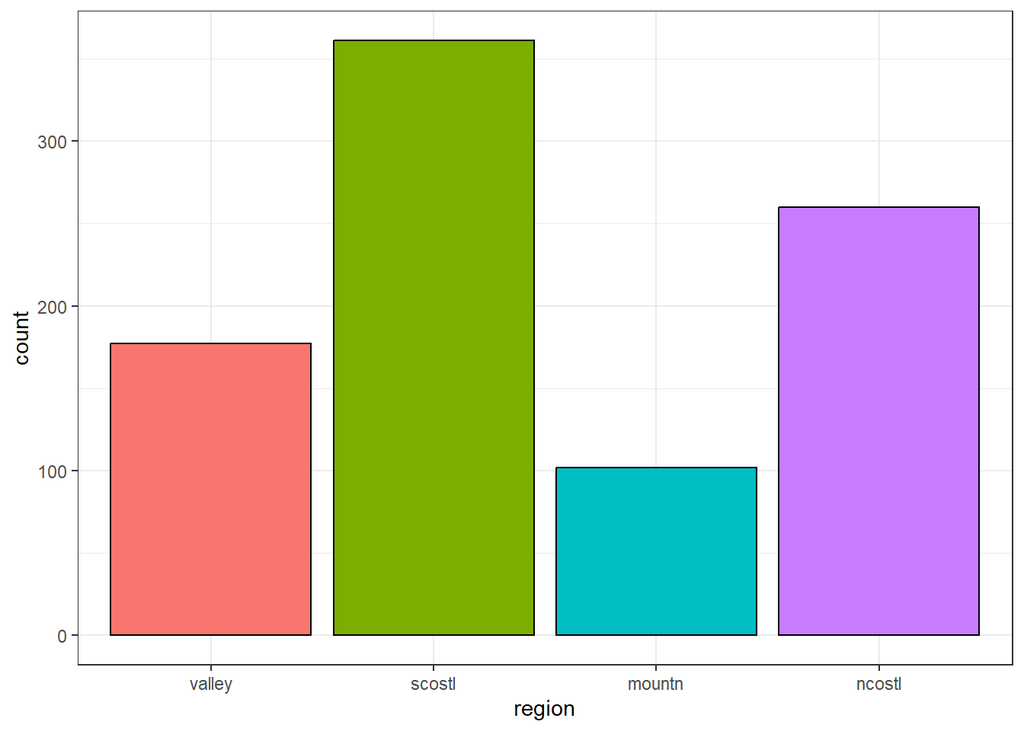

```r
ggplot(Heating)+
  geom_bar(aes(region, fill=region), color="black", show.legend = FALSE)+
  theme_bw()
```

```r
model2 <- mlogit(depvar ~ ic | region, Heating, shape = "wide", choice = "depvar", reflevel = "ec",
                 varying = c(3:7))

summary(model2)
```

```
##
## Call:
## mlogit(formula = depvar ~ ic | region, data = Heating, reflevel = "ec",
##     shape = "wide", choice = "depvar", varying = c(3:7), method = "nr")
##
## Frequencies of alternatives:choice
##       ec       er       gc       gr       hp
## 0.071111 0.093333 0.636667 0.143333 0.055556
##
## nr method
## 6 iterations, 0h:0m:0s
## g'(-H)^-1g = 0.000192
## successive function values within tolerance limits
##
## Coefficients :
##                    Estimate  Std. Error z-value  Pr(>|z|)
## (Intercept):er   0.60026296  0.37803680  1.5878  0.112322
## (Intercept):gc   2.03028891  0.29516076  6.8786 6.045e-12 ***
## (Intercept):gr   0.89557390  0.34321429  2.6094  0.009071 **
## (Intercept):hp   0.28142118  0.42207287  0.6668  0.504926
## ic              -0.00166573  0.00062007 -2.6864  0.007223 **
## regionscostl:er  0.04953858  0.44699277  0.1108  0.911754
## regionscostl:gc  0.07371855  0.36192685  0.2037  0.838601
## regionscostl:gr  0.10263835  0.41405948  0.2479  0.804225
## regionscostl:hp -0.14496763  0.50052467 -0.2896  0.772098
## regionmountn:er -0.02228435  0.59062797 -0.0377  0.969903
## regionmountn:gc -0.08617193  0.47825549 -0.1802  0.857012
## regionmountn:gr  0.03599409  0.54612045  0.0659  0.947451
## regionmountn:hp -0.03937414  0.65470562 -0.0601  0.952044
## regionncostl:er -0.33843774  0.49386054 -0.6853  0.493161
## regionncostl:gc  0.23183246  0.38396435  0.6038  0.545986
## regionncostl:gr -0.32954624  0.45479104 -0.7246  0.468691
## regionncostl:hp -0.39942540  0.55412324 -0.7208  0.471018
## ---
## Signif. codes:  0 '***' 0.001 '**' 0.01 '*' 0.05 '.' 0.1 ' ' 1
##
## Log-Likelihood: -1012.5
## McFadden R^2:  0.0094891
## Likelihood ratio test : chisq = 19.4 (p.value = 0.11122)
```

# modelo 3. considera costos de Instalacion y Operacion

```r
model3 <- mlogit(depvar ~ ic + oc, Heating, shape = "wide", choice = "depvar", reflevel = "ec", varying = c(3:12))

summary(model3)
```

```
##
## Call:
## mlogit(formula = depvar ~ ic + oc, data = Heating, reflevel = "ec",
##     shape = "wide", choice = "depvar", varying = c(3:12), method = "nr")
##
## Frequencies of alternatives:choice
##       ec       er       gc       gr       hp
## 0.071111 0.093333 0.636667 0.143333 0.055556
##
## nr method
## 6 iterations, 0h:0m:0s
## g'(-H)^-1g = 9.58E-06
## successive function values within tolerance limits
##
## Coefficients :
##                   Estimate  Std. Error z-value  Pr(>|z|)
## (Intercept):er  0.19459102  0.20424212  0.9527 0.3407184
## (Intercept):gc  0.05213336  0.46598878  0.1119 0.9109210
## (Intercept):gr -1.35058266  0.50715442 -2.6631 0.0077434 **
## (Intercept):hp -1.65884594  0.44841936 -3.6993 0.0002162 ***
## ic             -0.00153315  0.00062086 -2.4694 0.0135333 *
## oc             -0.00699637  0.00155408 -4.5019 6.734e-06 ***
## ---
## Signif. codes:  0 '***' 0.001 '**' 0.01 '*' 0.05 '.' 0.1 ' ' 1
##
## Log-Likelihood: -1008.2
## McFadden R^2:  0.013691
## Likelihood ratio test : chisq = 27.99 (p.value = 8.3572e-07)
```

```r
model3 <- mlogit(depvar ~ ic + oc, Heating, shape = "wide", choice = "depvar", reflevel = "ec", varying = c(3:12),type ="probabilities")

summary(model3)
```

```
##
## Call:
## mlogit(formula = depvar ~ ic + oc, data = Heating, reflevel = "ec",
##     shape = "wide", choice = "depvar", varying = c(3:12), type = "probabilities",
##     method = "nr")
##
## Frequencies of alternatives:choice
##       ec       er       gc       gr       hp
## 0.071111 0.093333 0.636667 0.143333 0.055556
##
## nr method
## 6 iterations, 0h:0m:0s
## g'(-H)^-1g = 9.58E-06
## successive function values within tolerance limits
##
## Coefficients :
##                   Estimate  Std. Error z-value  Pr(>|z|)
## (Intercept):er  0.19459102  0.20424212  0.9527 0.3407184
## (Intercept):gc  0.05213336  0.46598878  0.1119 0.9109210
## (Intercept):gr -1.35058266  0.50715442 -2.6631 0.0077434 **
## (Intercept):hp -1.65884594  0.44841936 -3.6993 0.0002162 ***
## ic             -0.00153315  0.00062086 -2.4694 0.0135333 *
## oc             -0.00699637  0.00155408 -4.5019 6.734e-06 ***
## ---
## Signif. codes:  0 '***' 0.001 '**' 0.01 '*' 0.05 '.' 0.1 ' ' 1
##
## Log-Likelihood: -1008.2
## McFadden R^2:  0.013691
## Likelihood ratio test : chisq = 27.99 (p.value = 8.3572e-07)
```

```r
utilidad_model3 <- as.data.frame(model3$linpred)

Heating_new <- Heating |> mutate(ic.new = ic.ec+200, oc.new = oc.ec*0.75, utilidades_new = coefficients(model3)[6]*oc.new + coefficients(model3)[6]*oc.new)

utilidad_model3 <- utilidad_model3 |> mutate(new = Heating_new$utilidades_new, p_ec = exp(ec)/( exp(ec)+exp(er)+exp(gc)+exp(gr)+exp(hp)+exp(new)),
                                             p_er = exp(er)/ (exp(ec)+ exp(er)+exp(gc)+exp(gr)+exp(hp)+exp(new)),
                                             p_gc = exp(gc)/ (exp(ec)+ exp(er)+exp(gc)+exp(gr)+exp(hp)+exp(new)),
                                             p_gr = exp(gr)/ (exp(ec)+ exp(er)+exp(gc)+exp(gr)+exp(hp)+exp(new)),
                                             p_hp = exp(hp)/ (exp(ec)+ exp(er)+exp(gc)+exp(gr)+exp(hp)+exp(new)),
                                             p_new = exp(new)/ (exp(ec)+ exp(er)+exp(gc)+exp(gr)+exp(hp)+exp(new)))

probabilidades_nuevas <- utilidad_model3 |> dplyr::select(p_ec:p_new)
apply(probabilidades_nuevas, 2, mean)
```

```
##       p_ec       p_er       p_gc       p_gr       p_hp      p_new
## 0.06717017 0.08871081 0.60729910 0.13667318 0.05292281 0.04722393
```

```r
choice_pred <- apply(model1$probabilities, 1,function(x) names(x)[which(x==max(x))])

Heating_pred <- Heating |> mutate(choice_pred=choice_pred, .before = 3)
table(Heating_pred$depvar,Heating_pred$choice_pred)
```

```
##
##       gc
##   gc 573
##   gr 129
##   ec  64
##   er  84
##   hp  50
```